# CB-mouthColor

Justin Mann

4/1/2021

```r
library(RColorBrewer); #brewer.pal(n=8, name = "Dark2") #;display.brewer.pal(n = 8, name = "Dark2")
library(tidyverse); theme_set(theme_classic()) #ggplot2, dplyr, tibble, etc.
library(plotly) #use ggplotly() for interactive plots with scoll-over IDs
library(knitr) #use kable() to make formatted tables
library(kableExtra)
library(Rtsne)
library(glmmTMB)
library(lme4)
library(sjPlot)
library(ggpubr) #ggarrange() figure wraps
library(plyr)
library(ggeffects) #ggpredict
library(rstanarm) #stan models
library(shinystan) #stan model evaluation >launch_shinystan_demo()
library(loo) #loo() to compare fits between bayesian models
library(MuMIn) #dredge, model averaging
library(AICcmodavg) #aictab() for AICc model comparisons
library(coin) #permutation test for ratios with independence_test()
library(janitor) #get_dupes() finds and prints duplicates
```

### **Read in mouth color data (mc)**

**Replace zeros with NAs, sort and filter by age (23-27)**

```r
mc=tibble(read.csv("CB-mouthColor.csv", h=T)) #N=225
#replace zeros with NAs in morphometrics
mc[mc==0] <- NA
#sort by year > family > id
mc <- mc %>% arrange(year, family, id) #N=225
#filter to include only ages 23-27
mc <- mc %>% filter(between(age,23,27)) #N=141
mc <- mc %>% drop_na(sex) #N=138
```

**Identify duplicate records in mc**

```r
mc %>% get_dupes(id)
```

```
## # A tibble: 8 x 67
##   id       dupe_count   row family   year   age sex   tongY1 palY1 meanY1 tongM1
##   <chr>         <int> <int> <chr>   <int> <int> <chr>  <int> <int>  <int>  <int>
## 1 42 ROWA~          2   118 42 ROW~  2004    24 F         60    50     55     80
## 2 42 ROWA~          2   137 42 ROW~  2004    24 F         60    50     55     70
## 3 53 ROWA~          2   119 53 ROW~  2004    24 F         60    50     55     70
## 4 53 ROWA~          2   138 53 ROW~  2004    24 F         50    30     40     60
## 5 64 ROWA~          2   120 64 ROW~  2004    24 F         70    40     55     80
## 6 64 ROWA~          2   139 64 ROW~  2004    24 F         60    40     50     60
## 7 75 ROWA~          2   121 75 ROW~  2004    24 F         60    40     50     70
## 8 75 ROWA~          2   140 75 ROW~  2004    24 F         50    50     50     50
## # ... with 56 more variables: palM1 <int>, meanM1 <dbl>, sat1 <dbl>,
## #   hue1 <dbl>, tongY2 <int>, palY2 <int>, meanY2 <int>, tongM2 <int>,
## #   palM2 <int>, meanM2 <dbl>, sat2 <dbl>, hue2 <dbl>, bodTemp1 <dbl>,
## #   bodTemp2 <dbl>, diffBodTemp <dbl>, ambTemp1 <dbl>, ambTemp2 <dbl>,
## #   ambFinal <dbl>, broodSize <int>, bandTime1 <chr>, bandTime2 <chr>,
## #   handleTime <int>, bandOrder <int>, time1 <chr>, time2 <chr>,
## #   obtainTime <chr>, date <chr>, julDate <int>, mass <int>, tailLength <int>,
## #   tarsus <dbl>, wingChord <int>, sevenPrim <dbl>, expSevenPrim <dbl>,
## #   billNT <dbl>, billWidth <dbl>, billDepth <dbl>, TEC <dbl>, head <dbl>,
## #   skull <dbl>, timeOut1 <int>, timeOut2 <int>, obt1Max <dbl>, obt1Min <dbl>,
## #   obt1Max.1 <dbl>, obt1Min.1 <dbl>, t1MaxMinusHour <dbl>,
## #   t1MinMinusHour <dbl>, t1MeanMinusHour <dbl>, t1MaxAtBand <dbl>,
## #   t1MinAtBand <dbl>, t1MeanAtBand <dbl>, futureBreeder <int>,
## #   broodSize.1 <int>, familyProducedBreeder <int>, comments <chr>
```

For these duplicate records, one record for each individual is missing time 2 measurements. Therefore, I am keeping only the complete record for each individual. Removed = 42 ROWA04 (row 137), 53 ROWA04 (row 138), 64 ROWA04 (row 139), 75 ROWA04 (row 140)

```r
mc <- mc[-c(62,67,72,78),]#N=134
#mc %>% get_dupes() #double check...yep, no duplicates
```

```r
#females only
female.mc <- mc %>%
  filter(sex == "F") #N=79
#males only
male.mc <- mc %>%
  filter(sex == "M") #N=55
```

### **Read in nestling morphometrics data (nm)**

**Nestling morphometrics are being used here to boost sample size for calculating mass/tarsus residuals**  
**Replace zeros with NAs, sort and filter by age (23-27)**

```r
nm=tibble(read.csv("nestlingMorph.csv", h=T))
#replace zeros with NAs in morphometrics
nm[nm==0] <- NA
#remove nestlingMeasurementNumber
nm <- nm[,-1]
#sort by year > nestName > id
nm <- nm %>% arrange(year, nestName ,id)
#filter to include only ages 23-27
nm <- nm %>% filter(between(age, 23, 27))
```

**Create subset of nm including only sexed birds (N=503; females=268; males=235)**

```r
#subset nm to include only sexed birds and remove NAs from mass & tarsus
sexed.nm <- nm %>% drop_na(sex, tarsus, mass) #N=503
#make sex a factor rather than character
sexed.nm$sex <- as.factor(sexed.nm$sex)
#females only
female.nm <- sexed.nm %>%
  filter(sex == "F") #N=268
#males only
male.nm <- sexed.nm %>%
  filter(sex == "M") #N=235
```

### **Do we need to control for repeated measurements of birds in mass~tarsus.mdl?**

The code below compares a linear model (lm) and a linear mixed effects model (lmer), which controls for repeated measurements of the same birds during multiple climbs.

### 1. Use lm() to run linear model with no random effects

**Run lm() and plot residuals**

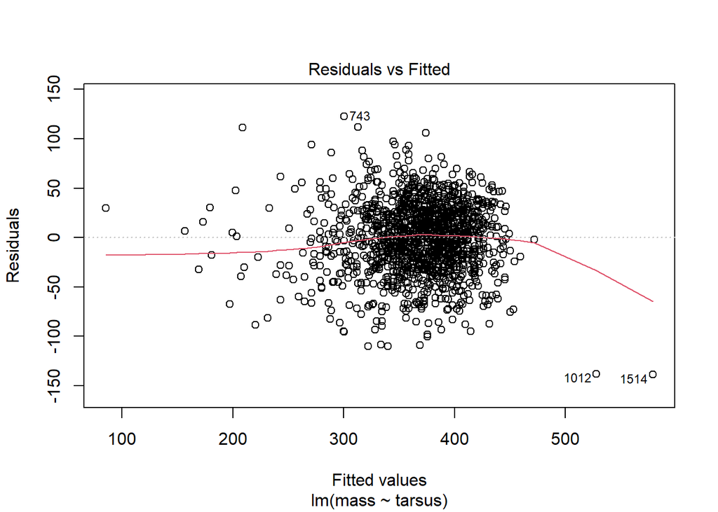

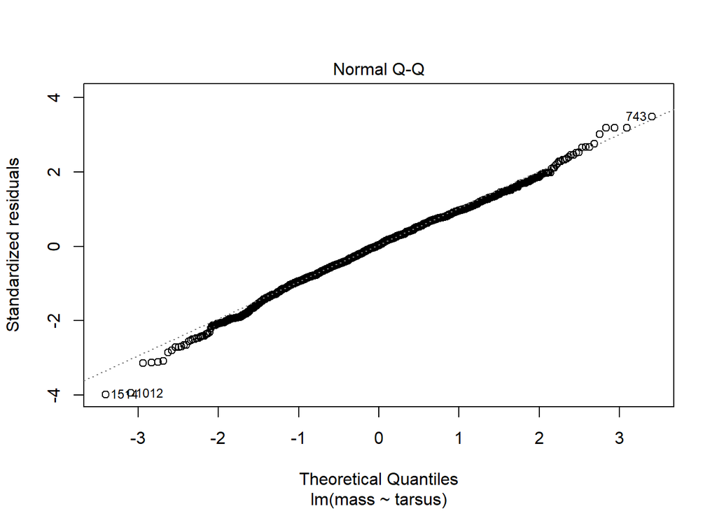

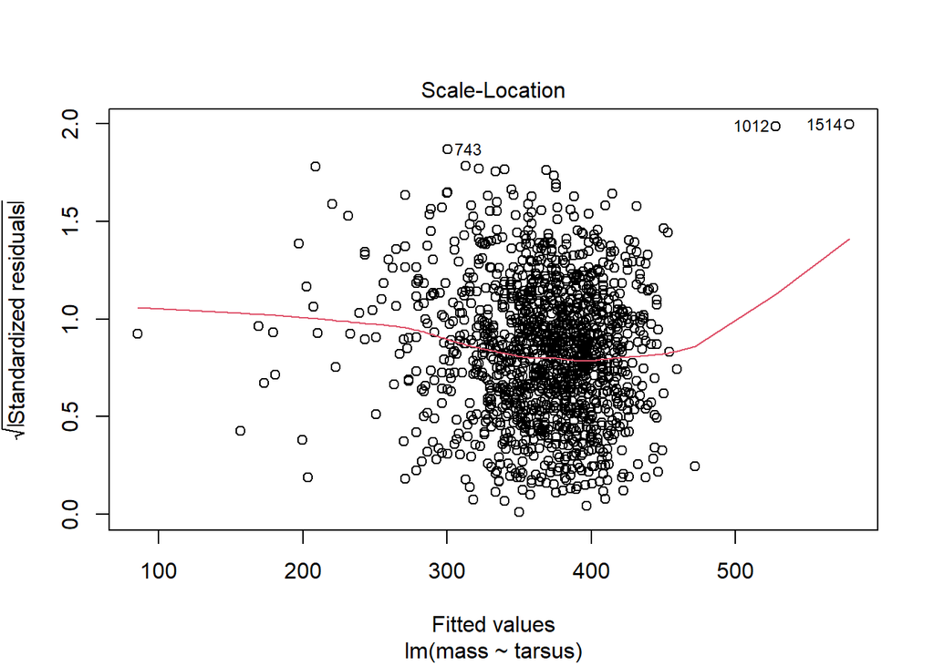

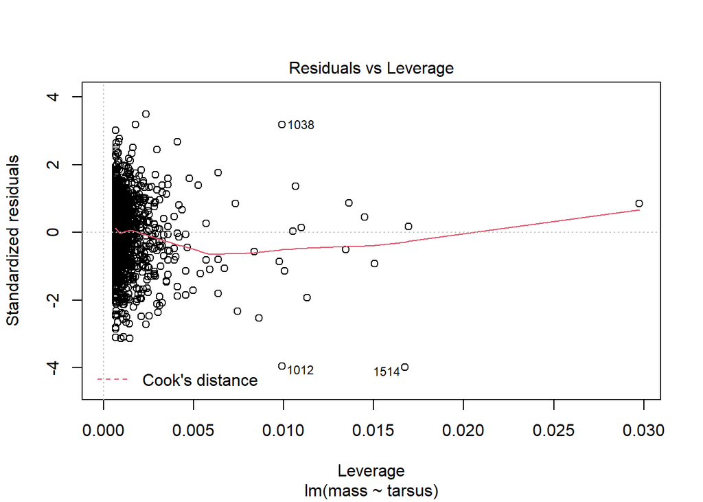

```r
noRandId.mdl_outliers <- lm(mass~tarsus, data = nm)
plot(noRandId.mdl_outliers)
```

Residual plots identify the following individuals as outliers.

```r
nm[c(437,743,1012,1038,1514),c(5,10,22)] %>%
  kbl() %>%
  kable_paper("hover", full_width = F, position = "left")
```

| id | tarsus | mass |
| --- | --- | --- |
| P4 WHIT98 | 36.2 | 115 |
| 73 WARC04 | 53.1 | 423 |
| IP GUTL08 | 71.0 | 390 |
| EY MCUN08 | 45.9 | 320 |
| VO MINO18 | 75.0 | 440 |

**Remove the identified outliers, rerun lm() and plot residuals again**

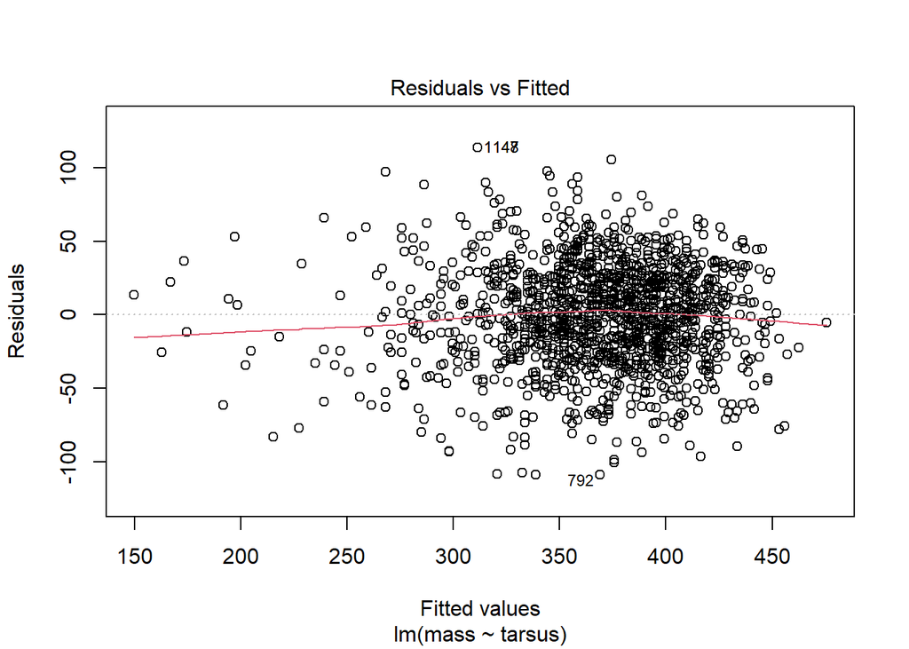

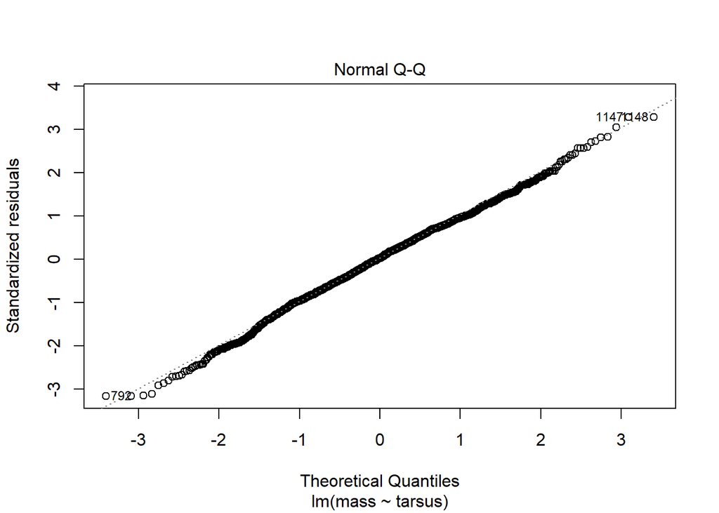

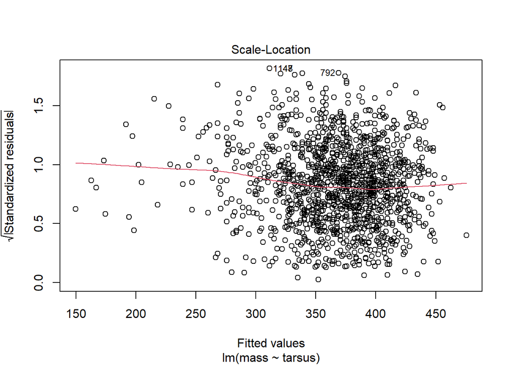

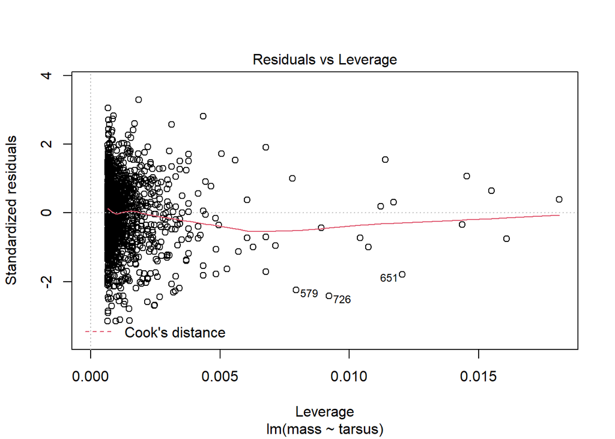

```r
tarsusMass.nm <- nm[-c(437,743,1012,1038,1514),] #n=1531 (five birds removed confirmed)
#drop NAs from tarsus and mass
tarsusMass.nm <- drop_na(tarsusMass.nm, tarsus, mass) #N=1513
noRandId.mdl2 <- lm(mass~tarsus, data = tarsusMass.nm)
plot(noRandId.mdl2)
```

Residual distributions improved

**Model summary**

```r
summary(noRandId.mdl2)
```

```
##
## Call:
## lm(formula = mass ~ tarsus, data = tarsusMass.nm)
##
## Residuals:
##      Min       1Q   Median       3Q      Max
## -109.110  -22.309    1.089   24.576  113.718
##
## Coefficients:
##             Estimate Std. Error t value Pr(>|t|)
## (Intercept) -399.734     16.043  -24.92   <2e-16 ***
## tarsus        13.143      0.274   47.97   <2e-16 ***
## ---
## Signif. codes:  0 '***' 0.001 '**' 0.01 '*' 0.05 '.' 0.1 ' ' 1
##
## Residual standard error: 34.56 on 1511 degrees of freedom
## Multiple R-squared:  0.6036, Adjusted R-squared:  0.6033
## F-statistic:  2301 on 1 and 1511 DF,  p-value: < 2.2e-16
```

```r
#   kbl(caption = "Linear Model: mass tarsus index") %>%
#   kable_classic(full_width = F, position = "left", html_font = "Cambria")
```

### 2. Use lmer() to run a mixed effects model that controls for birds with repeated measurements

We can only directly compare results from a linear model and a linear mixed effects model by using regular Maximum Likelihood (ML). However, the default likelihood estimation for lmer() models Random Effects Maximum Likelihood (REML).  
https://stackoverflow.com/questions/24019807/how-to-compare-a-model-with-no-random-effects-to-a-model-with-a-random-effect-us

The lmer() argument ‘REML=FALSE’ implements ML estimation instead.

**We use the same dataframe as above, age filtered, no NAs and outliers already removed**

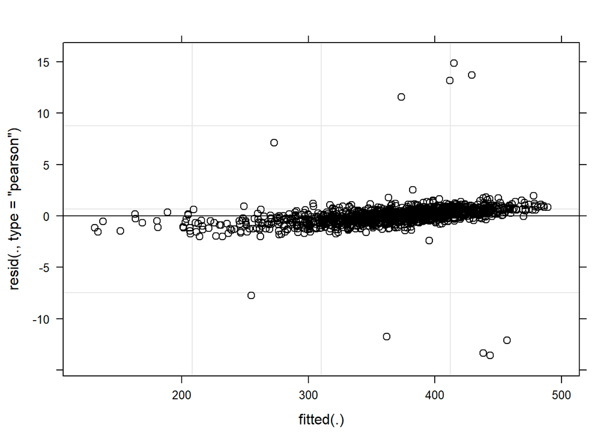

```r
randId.mdl <- lmer(mass~tarsus + (1|id), data = tarsusMass.nm, REML = FALSE)
plot(randId.mdl, col="black")
```

**Summary of mixed effect model**

```r
summary(randId.mdl)
```

```
## Linear mixed model fit by maximum likelihood  ['lmerMod']
## Formula: mass ~ tarsus + (1 | id)
##    Data: tarsusMass.nm
##
##      AIC      BIC   logLik deviance df.resid
##  14786.3  14807.6  -7389.2  14778.3     1509
##
## Scaled residuals:
##     Min      1Q  Median      3Q     Max
## -2.9088 -0.0832  0.0052  0.0891  3.1842
##
## Random effects:
##  Groups   Name        Variance Std.Dev.
##  id       (Intercept) 1164.30  34.122
##  Residual               21.84   4.674
## Number of obs: 1513, groups:  id, 1445
##
## Fixed effects:
##             Estimate Std. Error t value
## (Intercept) -388.728     15.922  -24.41
## tarsus        12.944      0.272   47.59
##
## Correlation of Fixed Effects:
##        (Intr)
## tarsus -0.998
```

**Now, directly compare the lm() and lmer() models**

```r
AIC(noRandId.mdl2,randId.mdl) %>%
  kbl(caption = "lm() vs. lmer(): mass~tarsus") %>%
  kable_classic(full_width = F, position = "left", html_font = "Cambria")
```

lm() vs. lmer(): mass~tarsus

|  | df | AIC |
| --- | --- | --- |
| noRandId.mdl2 | 3 | 15018.25 |
| randId.mdl | 4 | 14786.30 |

lmer() model does a better job at explaining variance with the inclusion of a random effect

### Plot–weight by tarsus: no sex filter (N=1513)

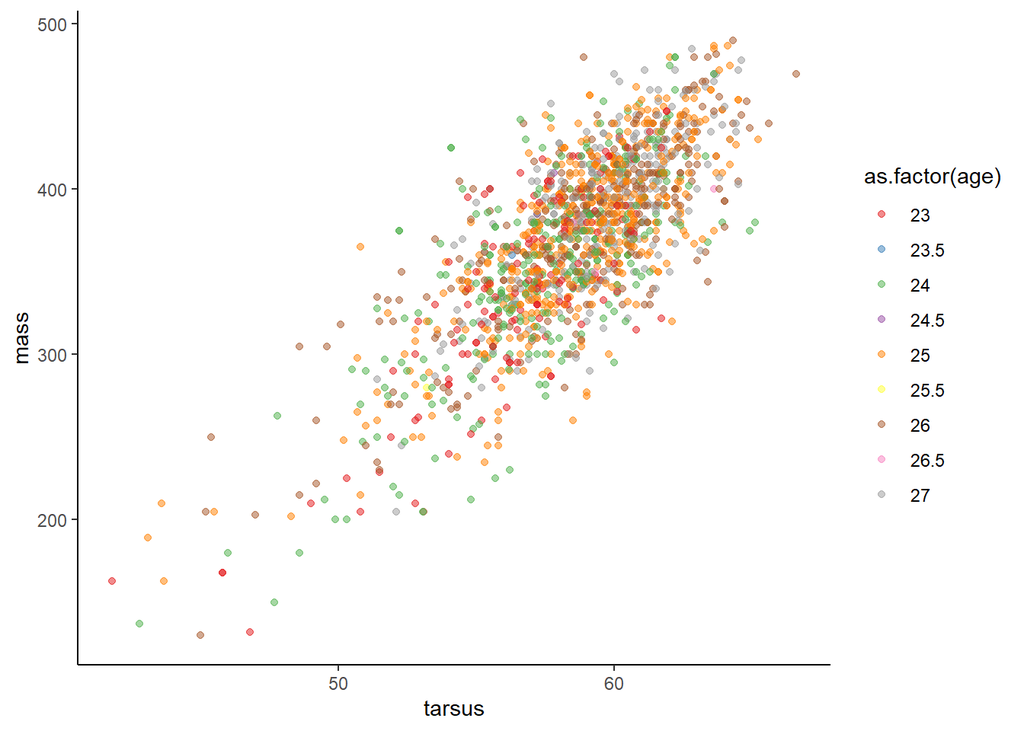

```r
tarsusMass.nm %>%
  ggplot(aes(x=tarsus,y=mass,color=as.factor(age)))+
  geom_point(alpha=0.5)+
  scale_color_brewer(palette = "Set1")
```

### Plot–mass distribution by sex

**Only includes sexed individuals (N=503)**

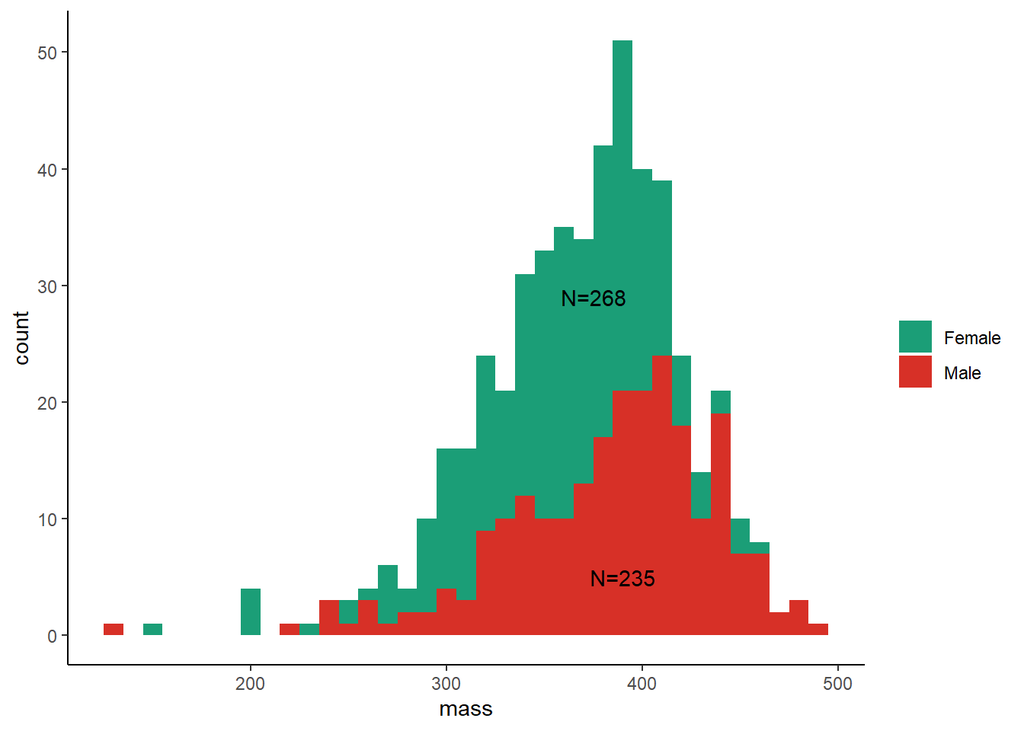

```r
sexed.nm %>%
  ggplot(aes(mass, fill=sex))+
  geom_histogram(binwidth = 10)+
  scale_fill_manual(values = c("#1B9E77", "#D73027"),
                    name = "",
                    labels = c("Female","Male"))+
  annotate(geom = "text", x=375, y=29, label="N=268")+
  annotate(geom = "text", x=390, y=5, label="N=235")
```

### Plot–tarsus distribution by sex

**Only includes sexed individuals (N=503)**

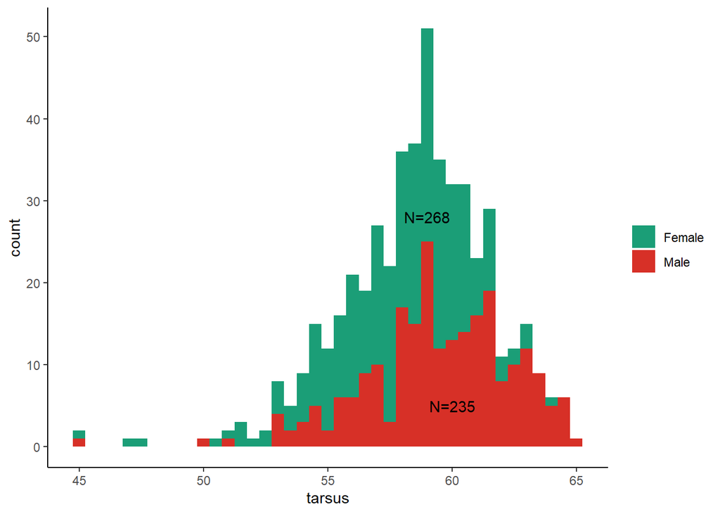

```r
sexed.nm %>%
  ggplot(aes(tarsus, fill=sex))+
  geom_histogram(binwidth = 0.5)+
  scale_fill_manual(values = c("#1B9E77", "#D73027"),
                    name = "",
                    labels = c("Female","Male"))+
  annotate(geom = "text", x=59, y=28, label="N=268")+
  annotate(geom = "text", x=60, y=5, label="N=235")
```

### Plot–mass by tarsus with sex filter (N=503)

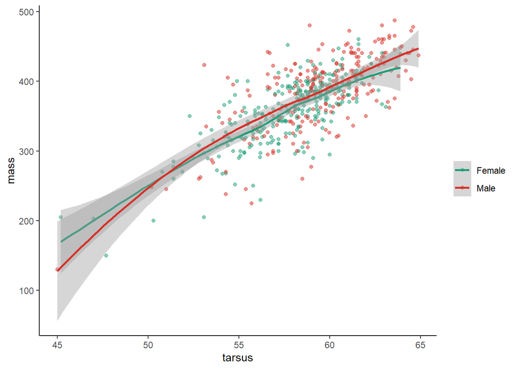

```r
sexed.nm %>%
  ggplot(aes(x=tarsus,y=mass,color=sex))+
  geom_point(alpha=0.5)+
  geom_smooth()+
  scale_color_manual(values = c("#1B9E77", "#D73027"),
                    name = "",
                    labels = c("Female","Male"))
```

### Calculate mass/tarsus ratio and append a ratio column to sexed.nm

```r
sexed.nm$ratio <- sexed.nm$mass/sexed.nm$tarsus
```

### Permutation test to assess independence of male and female ratios

reference: https://stats.stackexchange.com/questions/23152/test-for-significant-difference-in-ratios-of-normally-distributed-random-variabl

```r
independence_test(ratio~sex, data = sexed.nm)
```

```
##
##  Asymptotic General Independence Test
##
## data:  ratio by sex (F, M)
## Z = -4.6465, p-value = 3.376e-06
## alternative hypothesis: two.sided
```

This result doesn’t indicate the direction of the relationship, but simply indicates that the female ratio is statistically different than the male ratio. This suggests that modeling male and female mouth color separately is likely best.

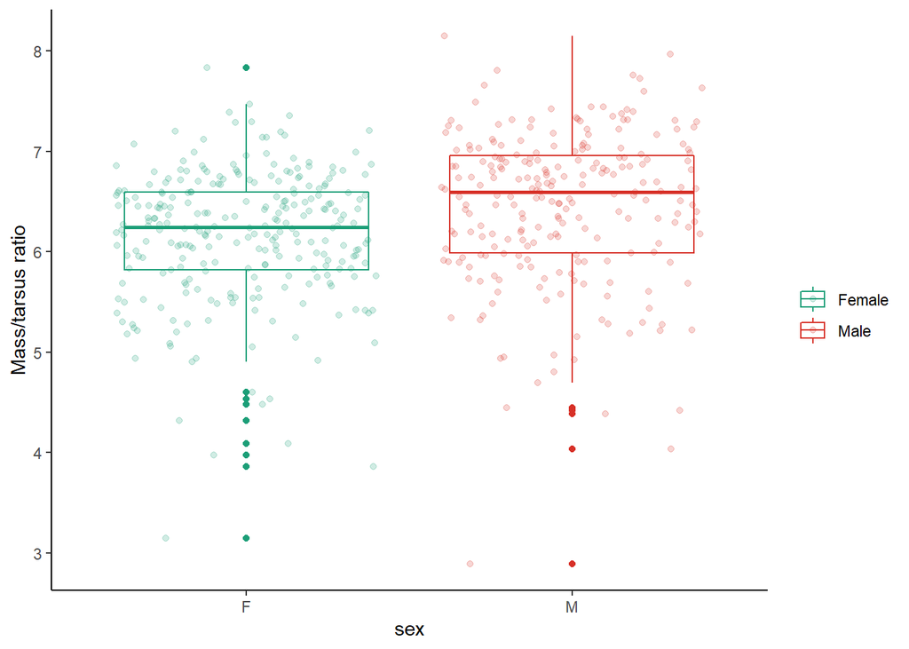

```r
sexed.nm %>%
  ggplot(aes(x=sex, y=ratio, color=sex))+
  geom_boxplot()+
  ylab("Mass/tarsus ratio")+
  scale_color_manual(values = c("#1B9E77", "#D73027"),
                    name = "",
                    labels = c("Female","Male"))+
  geom_jitter(alpha=0.2)
```

### Create the female mass~tarsus residual index

```r
femaleIndex.lm <- lm(mass~tarsus, female.nm)
summary(femaleIndex.lm)
```

```
##
## Call:
## lm(formula = mass ~ tarsus, data = female.nm)
##
## Residuals:
##      Min       1Q   Median       3Q      Max
## -106.011  -16.793    2.398   18.162   96.341
##
## Coefficients:
##              Estimate Std. Error t value Pr(>|t|)
## (Intercept) -400.1482    39.9747  -10.01   <2e-16 ***
## tarsus        13.0989     0.6907   18.96   <2e-16 ***
## ---
## Signif. codes:  0 '***' 0.001 '**' 0.01 '*' 0.05 '.' 0.1 ' ' 1
##
## Residual standard error: 31.09 on 266 degrees of freedom
## Multiple R-squared:  0.5748, Adjusted R-squared:  0.5732
## F-statistic: 359.6 on 1 and 266 DF,  p-value: < 2.2e-16
```

**Check residual distributions**

*Q-Q plot looks a little non-normal, probably seeing the effects of reduced sample size by separating sexes.

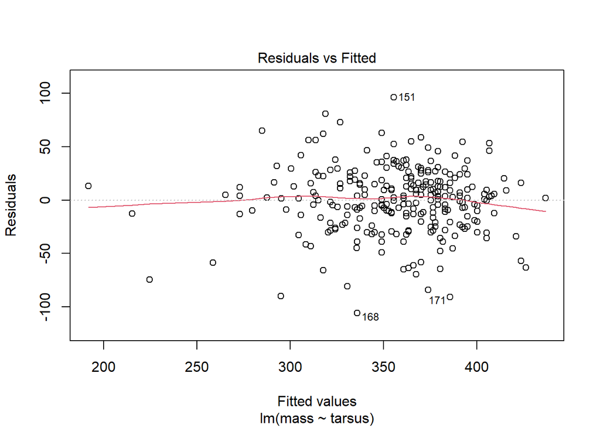

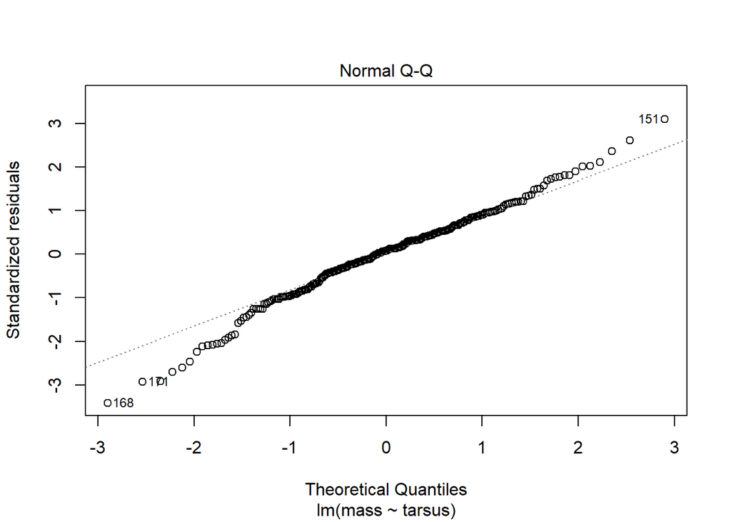

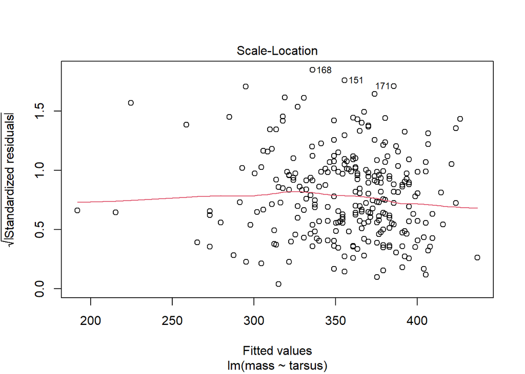

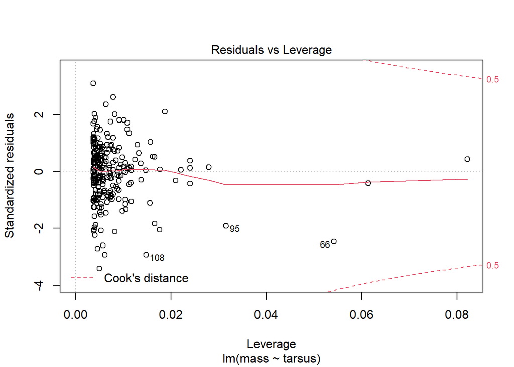

```r
plot(femaleIndex.lm)
```

### Plot–female mass~tarsus

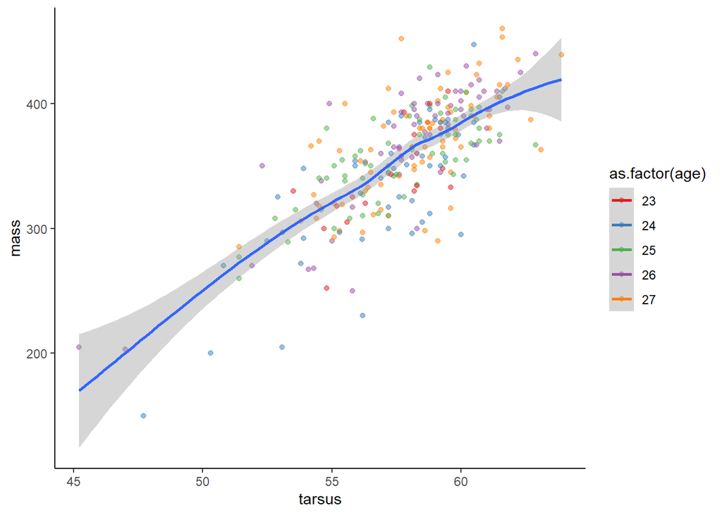

```r
female.nm %>%
  ggplot(aes(x=tarsus, y=mass, color=as.factor(age)))+
  geom_point(alpha = 0.5)+
  geom_smooth(aes(group=1))+
  scale_color_brewer(palette = "Set1")
```

### Create male mass~tarsus residual index

```r
maleIndex.lm <- lm(mass~tarsus, male.nm)
summary(maleIndex.lm)
```

```
##
## Call:
## lm(formula = mass ~ tarsus, data = male.nm)
##
## Residuals:
##      Min       1Q   Median       3Q      Max
## -112.780  -23.824    1.778   26.411  118.573
##
## Coefficients:
##              Estimate Std. Error t value Pr(>|t|)
## (Intercept) -367.7149    50.4700  -7.286 4.91e-12 ***
## tarsus        12.6580     0.8477  14.932  < 2e-16 ***
## ---
## Signif. codes:  0 '***' 0.001 '**' 0.01 '*' 0.05 '.' 0.1 ' ' 1
##
## Residual standard error: 38.67 on 233 degrees of freedom
## Multiple R-squared:  0.489,  Adjusted R-squared:  0.4868
## F-statistic:   223 on 1 and 233 DF,  p-value: < 2.2e-16
```

**Plot residuals**

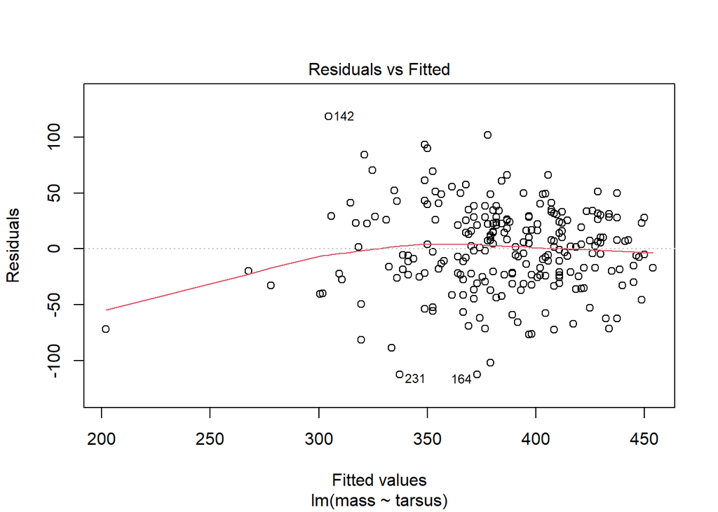

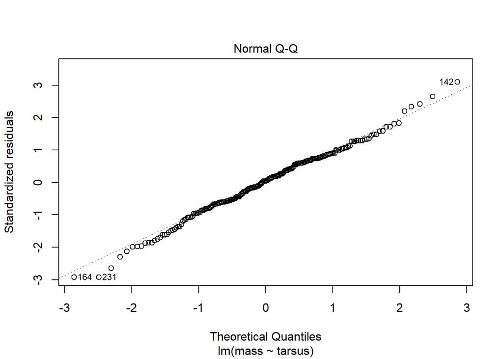

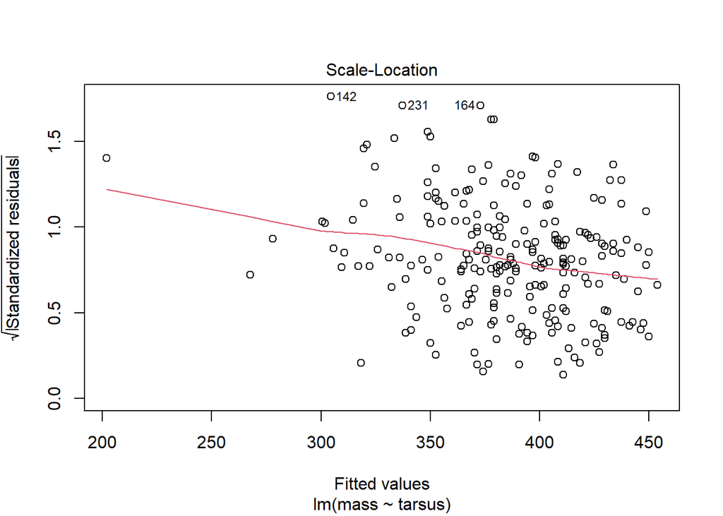

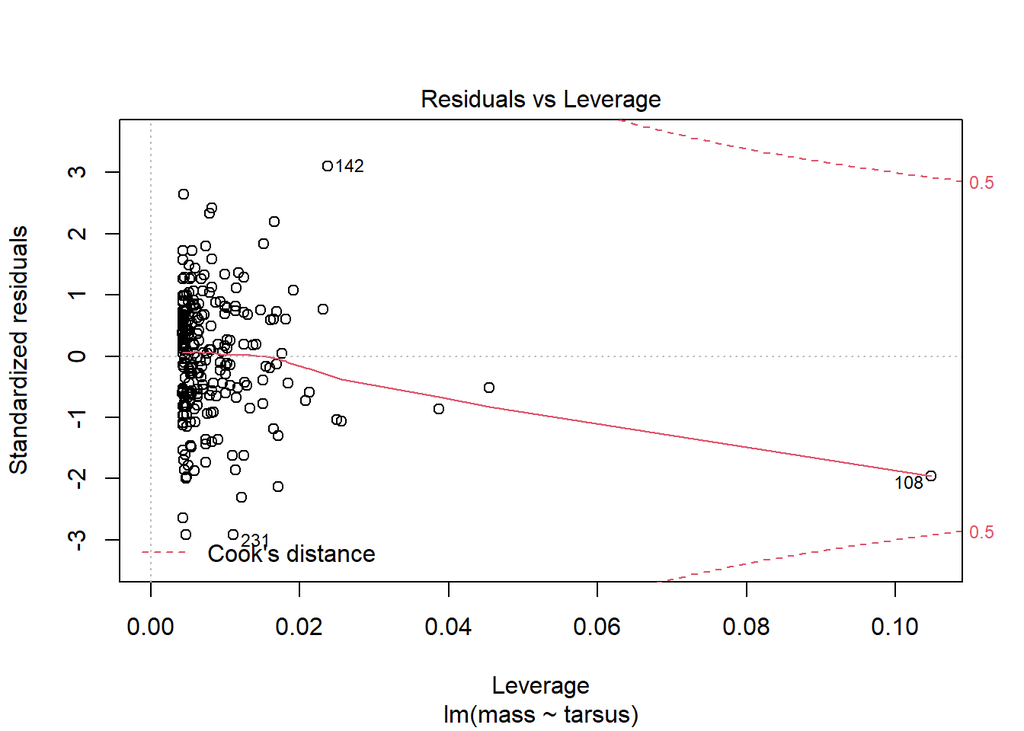

```r
plot(maleIndex.lm)
```

### Plot–male tarsus~mass

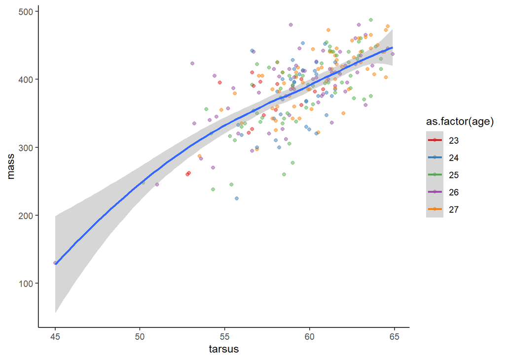

```r
male.nm %>%
  ggplot(aes(x=tarsus, y=mass, color=as.factor(age)))+
  geom_point(alpha = 0.5)+
  geom_smooth(aes(group=1))+
  scale_color_brewer(palette = "Set1")
```

**Create dataframes containing id and residuals**

```r
male.nm$residuals <- maleIndex.lm$residuals
female.nm$residuals <- femaleIndex.lm$residuals
joinMaleResidual <- data.frame(id = male.nm$id,
                               residuals = male.nm$residuals)
joinFemaleResidual <- data.frame(id = female.nm$id,
                                 residuals = female.nm$residuals)
```

**Join residuals with male and female mouth color data by common id**

```r
newFemale.mc <- left_join(female.mc,joinFemaleResidual, by="id")
female.mc$residuals <- newFemale.mc$residuals

newMale.mc <- left_join(male.mc,joinMaleResidual, by="id")
male.mc$residuals <- newMale.mc$residuals
bothSexResid <- data.frame(rbind(joinMaleResidual,joinFemaleResidual))

new.mc <- left_join(mc,bothSexResid, by="id")
new.mc$residuals
```

```
##   [1]  54.663879 -62.272625 -30.195470 -23.026230 -35.146201   7.762793
##   [7]  21.918883  10.169859 -62.045686 -71.896475  -4.237207 -24.927316
##  [13]  -3.943610 -36.348792 -63.518511 -44.748813 -65.513768 -44.514080
##  [19]  -5.109705 -80.771225  -5.630574 -14.930655   2.790587   1.498875
##  [25]  20.593553  35.043435 -71.577292  37.101272  27.072684 -14.955904
##  [31] -28.166882 -62.335837 -24.955904  19.119602  -9.729488 -21.919262
##  [37] -23.437913  -9.023940 -26.010791  25.918883  -8.666414  41.447056
##  [43] -39.010791 -55.527035 -42.172110 -16.893353  22.827890 -27.221768
##  [49]   4.692467  -5.771225   1.595842 -16.362420 -10.590247  -4.911877
##  [55]  -5.603202  -7.336121   4.004571  29.356277  -8.138293  -8.138293
##  [61]  26.481489 -23.151443 -20.927316 -20.927316  -6.551383   9.692467
##  [67] -45.096556 -45.096556  26.002358 118.573480  16.372450 -32.109705
##  [73] -32.109705  45.762793  90.004571  31.721055  62.890295  65.074974
##  [79]  23.059535  34.093693  56.187037  -4.432746  48.840844  66.296284
##  [85]  20.791381 -30.250357  38.422708   1.426603   7.567254  52.194208
##  [91]  40.106647  51.207162  96.340838  26.207162 -41.503072   9.580403
##  [97]  42.116711  35.890295  -1.514080 -28.617425 -21.729626 -25.198020
## [103] -29.930655 -52.677807 -38.856990  -7.278945 -20.067968 -33.222368
## [109] -10.753974   9.932032 -15.208619   9.980223 -37.032731 -35.435035
## [115] 102.156905 -61.138293 -25.307533 -90.786664 -58.067968   9.551815
## [121]   2.044096  58.932032  16.692467  37.778232   8.043435 -29.577292
## [127]  29.054829 -22.489732  21.220117  -6.617425   0.874856 -11.166882
## [133]  17.762793   7.664163
```

```r
mc$residuals <- new.mc$residuals
```

### Female only saturation 1 model

```r
femaleSat1.mdl <- lmer(sat1~age + residuals + bodTemp1 + ambTemp1 + timeOut1 + (1|family), data = female.mc)
summary(femaleSat1.mdl)
```

```
## Linear mixed model fit by REML ['lmerMod']
## Formula: sat1 ~ age + residuals + bodTemp1 + ambTemp1 + timeOut1 + (1 |
##     family)
##    Data: female.mc
##
## REML criterion at convergence: 532.7
##
## Scaled residuals:
##      Min       1Q   Median       3Q      Max
## -1.93174 -0.43461  0.05654  0.54941  1.29807
##
## Random effects:
##  Groups   Name        Variance Std.Dev.
##  family   (Intercept) 167.0    12.92
##  Residual             100.5    10.02
## Number of obs: 66, groups:  family, 45
##
## Fixed effects:
##              Estimate Std. Error t value
## (Intercept) 199.98847  103.69133   1.929
## age          -4.20322    1.72552  -2.436
## residuals     0.13913    0.06622   2.101
## bodTemp1      0.39742    2.61236   0.152
## ambTemp1      0.40175    0.66774   0.602
## timeOut1      0.21590    0.19737   1.094
##
## Correlation of Fixed Effects:
##           (Intr) age    resdls bdTmp1 ambTm1
## age       -0.303
## residuals  0.227 -0.329
## bodTemp1  -0.894 -0.137 -0.091
## ambTemp1   0.343  0.210  0.002 -0.556
## timeOut1   0.028 -0.104  0.117 -0.036  0.111
```

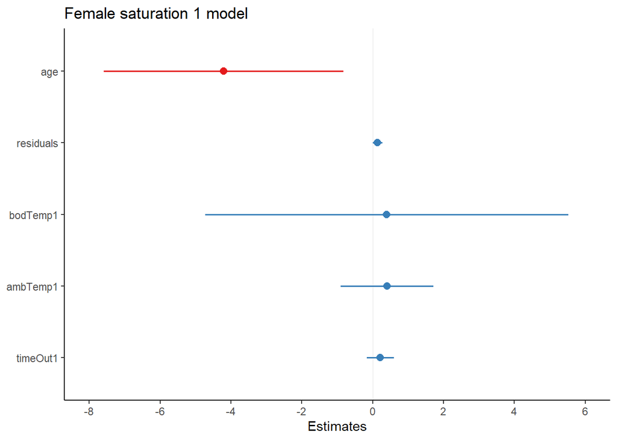

```r
plot_model(femaleSat1.mdl,
           title = "Female saturation 1 model")
```

```r
confint(femaleSat1.mdl)
```

```
## Computing profile confidence intervals ...
```

```
##                    2.5 %      97.5 %
## .sig01        6.49535545  17.4990900
## .sigma        6.88796379  13.9115311
## (Intercept) -21.96803572 406.2127781
## age          -7.55081415  -0.9036242
## residuals     0.01358878   0.2648177
## bodTemp1     -4.61361497   5.8605955
## ambTemp1     -0.90563062   1.7122303
## timeOut1     -0.20035742   0.6116318
```

### Bayesian female sat1 model

```r
stan_femaleSat1.mdl <- stan_glmer(sat1~age + residuals + bodTemp1 + ambTemp1 + timeOut1 + (1|family),
           data = female.mc, algorithm = "sampling",iter = 5000,
           prior = normal(), prior_intercept = normal(),chains = 10,seed = 12345)
summary(stan_femaleSat1.mdl)
```

```
##
## Model Info:
##  function:     stan_glmer
##  family:       gaussian [identity]
##  formula:      sat1 ~ age + residuals + bodTemp1 + ambTemp1 + timeOut1 + (1 |
##     family)
##  algorithm:    sampling
##  sample:       25000 (posterior sample size)
##  priors:       see help('prior_summary')
##  observations: 66
##  groups:       family (45)
##
## Estimates:
##                                         mean    sd      10%     50%     90%
## (Intercept)                              57.9   105.9   -77.5    58.7   192.6
## age                                      -0.1     2.4    -3.2    -0.1     3.0
## residuals                                 0.1     0.1     0.0     0.1     0.3
## bodTemp1                                 -0.8     2.1    -3.5    -0.8     2.0
## ambTemp1                                 -1.3     1.3    -3.0    -1.4     0.4
## timeOut1                                  0.3     0.4    -0.2     0.3     0.9
## b[(Intercept) family:10_CAFO04]         126.9    13.4   110.1   127.0   143.6
## b[(Intercept) family:19_HAWA04]         131.4    13.6   114.1   131.6   148.5
## b[(Intercept) family:20_HAWA04]         151.1    13.6   133.9   151.4   168.2
## b[(Intercept) family:21_CAFO04]         127.4    12.9   111.4   127.4   143.6
## b[(Intercept) family:29_LOCO04]         161.3    16.1   140.9   161.6   181.3
## b[(Intercept) family:31_HAWA04]         143.6    13.6   126.5   143.7   160.8
## b[(Intercept) family:39_FOWA04]         130.1    12.9   113.8   130.2   146.2
## b[(Intercept) family:41_LOCO04]         137.8    16.9   116.2   138.1   158.8
## b[(Intercept) family:42_ROWA04]         134.6    10.4   121.4   134.7   147.7
## b[(Intercept) family:43_BRBI04]         118.5    13.9   101.1   118.7   135.8
## b[(Intercept) family:52_LOCO04]         148.5    16.4   127.7   148.7   169.0
## b[(Intercept) family:53_ROWA04]         116.0    10.9   102.2   116.2   129.7
## b[(Intercept) family:63_MINE04]         115.5    13.5    98.4   115.5   132.4
## b[(Intercept) family:64_ROWA04]         128.0    12.0   112.9   128.2   142.8
## b[(Intercept) family:65_BRBI04]         121.4    14.0   103.7   121.5   138.9
## b[(Intercept) family:75_ROWA04]         117.7    11.7   103.0   117.8   132.3
## b[(Intercept) family:76_EPIN04]         116.8    15.4    97.5   117.1   135.9
## b[(Intercept) family:85_MINE04]          94.6    15.6    74.8    94.7   114.2
## b[(Intercept) family:87_EPIN04]         133.4    16.8   112.1   133.8   154.2
## b[(Intercept) family:96_MINE04]         102.9    14.1    85.3   103.1   120.6
```

[output cut: 78 more lines]

```
## b[(Intercept) family:LN_LRI205]        0.1  1.0 15014
## b[(Intercept) family:LRIS03]           0.1  1.0  9380
## b[(Intercept) family:MN_SEPG05]        0.1  1.0 12247
## b[(Intercept) family:ORHA05]           0.1  1.0 19757
## b[(Intercept) family:PELI05]           0.1  1.0 10127
## b[(Intercept) family:ROGO05]           0.1  1.0 12151
## b[(Intercept) family:SWEG03]           0.2  1.0  5972
## b[(Intercept) family:TRUP03]           0.2  1.0 10588
## b[(Intercept) family:WILG05]           0.1  1.0 13819
## sigma                                  0.0  1.0  3057
## Sigma[family:(Intercept),(Intercept)] 68.2  1.0  1496
## mean_PPD                               0.0  1.0 19007
## log-posterior                          0.2  1.0  2105
##
## For each parameter, mcse is Monte Carlo standard error, n_eff is a crude measure of effective sample size, and Rhat is the potential scale reduction factor on split chains (at convergence Rhat=1).
```

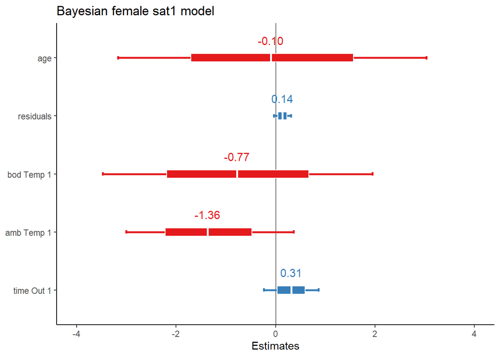

```r
plot_model(stan_femaleSat1.mdl,
           title = "Bayesian female sat1 model",
           bpe = "median",
           vline.color = "black",
           prob.inner = .50,
           prob.outer = .80,
           show.values = TRUE,
           value.offset = .3,
           line.size = 1)
```

### Male only saturation 1 model

```r
maleSat1.mdl <- lmer(sat1~age + residuals + bodTemp1 + ambTemp1 + timeOut1 + (1|family), data = male.mc)
summary(maleSat1.mdl)
```

```
## Linear mixed model fit by REML ['lmerMod']
## Formula: sat1 ~ age + residuals + bodTemp1 + ambTemp1 + timeOut1 + (1 |
##     family)
##    Data: male.mc
##
## REML criterion at convergence: 295.1
##
## Scaled residuals:
##      Min       1Q   Median       3Q      Max
## -1.20445 -0.47455  0.04476  0.29327  1.91910
##
## Random effects:
##  Groups   Name        Variance Std.Dev.
##  family   (Intercept) 122.45   11.066
##  Residual              94.24    9.708
## Number of obs: 38, groups:  family, 27
##
## Fixed effects:
##              Estimate Std. Error t value
## (Intercept) 151.02729   94.78703   1.593
## age          -3.42065    2.11050  -1.621
## residuals     0.11972    0.07597   1.576
## bodTemp1      0.55540    2.40481   0.231
## ambTemp1      1.58763    0.87832   1.808
## timeOut1      0.05542    0.18531   0.299
##
## Correlation of Fixed Effects:
##           (Intr) age    resdls bdTmp1 ambTm1
## age       -0.312
## residuals  0.306 -0.167
## bodTemp1  -0.801 -0.299 -0.155
## ambTemp1  -0.008  0.367 -0.222 -0.353
## timeOut1  -0.007 -0.297 -0.165  0.205 -0.449
```

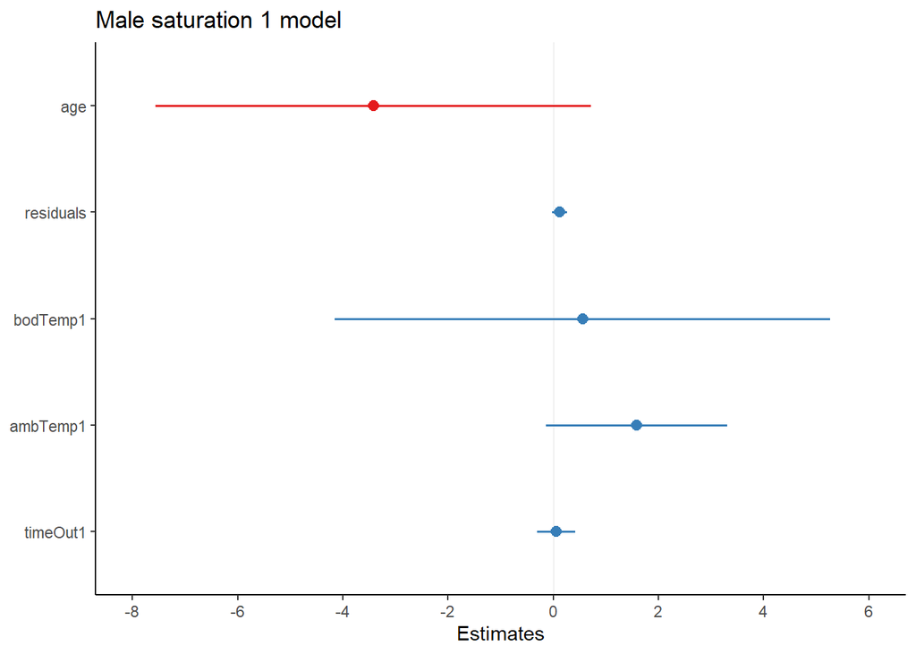

```r
plot_model(maleSat1.mdl,
           title = "Male saturation 1 model")
```

```r
confint(maleSat1.mdl)
```

```
## Computing profile confidence intervals ...
```

```
##                    2.5 %      97.5 %
## .sig01        0.00000000  15.4746721
## .sigma        6.19958272  14.8633285
## (Intercept) -24.70225533 348.3432271
## age          -7.35638114   0.4717888
## residuals    -0.02985887   0.3117471
## bodTemp1     -4.86979440   4.9888372
## ambTemp1     -0.03483666   3.2038967
## timeOut1     -0.32443551   0.4175888
```

### Bayesian male saturation 1 model

```r
stan_maleSat1.mdl <- stan_glmer(sat1~age + residuals + bodTemp1 + ambTemp1 + timeOut1 + (1|family),
           data = male.mc, algorithm = "sampling", iter = 5000,
           prior = normal(), prior_intercept = normal(),chains = 10,seed = 12345)
summary(stan_maleSat1.mdl)
```

```
##
## Model Info:
##  function:     stan_glmer
##  family:       gaussian [identity]
##  formula:      sat1 ~ age + residuals + bodTemp1 + ambTemp1 + timeOut1 + (1 |
##     family)
##  algorithm:    sampling
##  sample:       25000 (posterior sample size)
##  priors:       see help('prior_summary')
##  observations: 38
##  groups:       family (27)
##
## Estimates:
##                                         mean    sd      10%     50%     90%
## (Intercept)                             -53.3   118.8  -204.8   -53.7    99.3
## age                                      -0.4     2.5    -3.6    -0.4     2.8
## residuals                                 0.1     0.2    -0.2     0.1     0.3
## bodTemp1                                  0.7     2.2    -2.2     0.7     3.5
## ambTemp1                                  1.5     2.3    -1.4     1.5     4.4
## timeOut1                                  0.4     0.9    -0.7     0.5     1.6
## b[(Intercept) family:08_HAWA04]         127.1    22.6    98.6   127.3   155.3
## b[(Intercept) family:09_CAFO04]         101.2    21.8    74.1   101.4   128.2
## b[(Intercept) family:30_LOCO04]         129.3    30.5    90.6   129.3   167.7
## b[(Intercept) family:32_CAFO04]         120.1    19.9    95.2   120.5   144.7
## b[(Intercept) family:40_FOWA04]         116.5    20.3    91.1   116.9   141.7
## b[(Intercept) family:54_BRBI04]          95.4    23.8    65.6    95.4   125.4
## b[(Intercept) family:74_MINE04]         109.4    18.8    86.4   109.9   132.1
## b[(Intercept) family:96IR05]            117.7    23.2    88.7   118.0   146.6
## b[(Intercept) family:98_EPIN04]          98.5    22.9    69.6    98.7   127.0
## b[(Intercept) family:BURP03]             90.1    16.6    69.6    90.2   110.3
## b[(Intercept) family:CX_SLIM05]         107.7    39.3    57.5   107.5   157.9
## b[(Intercept) family:DBAR05]            109.3    16.4    88.6   109.5   129.9
## b[(Intercept) family:DYCE03]            119.6    24.3    89.2   119.7   150.1
## b[(Intercept) family:EHCR05]            122.0    25.1    89.8   122.1   153.8
## b[(Intercept) family:FOPA05]            122.1    22.6    93.7   122.5   150.5
## b[(Intercept) family:FOWA05]            127.5    12.7   111.7   127.6   143.3
## b[(Intercept) family:FU_SLIM05]          97.2    50.1    33.7    97.0   161.0
## b[(Intercept) family:HS_SLIM05]         100.5    55.0    31.2    99.7   170.1
## b[(Intercept) family:IR_SWEG05]         116.7    21.4    90.4   117.0   142.8
## b[(Intercept) family:LRIS03]             96.4    13.7    79.5    96.6   113.3
```

[output cut: 42 more lines]

```
## b[(Intercept) family:IR_SWEG05]        0.2  1.0 13083
## b[(Intercept) family:LRIS03]           0.1  1.0 20219
## b[(Intercept) family:MMUR03]           0.2  1.0 15990
## b[(Intercept) family:SEPG05]           0.2  1.0  7618
## b[(Intercept) family:STAD03]           0.2  1.0 12786
## b[(Intercept) family:STAD05]           0.1  1.0 13488
## b[(Intercept) family:SWEG03]           0.2  1.0  6836
## b[(Intercept) family:TRUP03]           0.1  1.0 13795
## b[(Intercept) family:WILG05]           0.2  1.0 14623
## sigma                                  0.1  1.0  2962
## Sigma[family:(Intercept),(Intercept)] 48.7  1.0  4085
## mean_PPD                               0.0  1.0 15747
## log-posterior                          0.2  1.0  2224
##
## For each parameter, mcse is Monte Carlo standard error, n_eff is a crude measure of effective sample size, and Rhat is the potential scale reduction factor on split chains (at convergence Rhat=1).
```

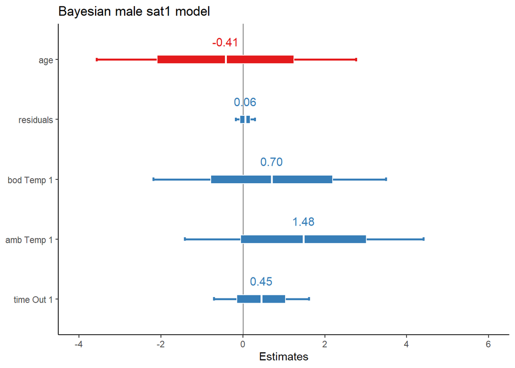

```r
plot_model(stan_maleSat1.mdl,
           title = "Bayesian male sat1 model",
           bpe = "median",
           vline.color = "black",
           prob.inner = .50,
           prob.outer = .80,
           show.values = TRUE,
           value.offset = .3,
           line.size = 1)
```

### Sat 1 model with sexes combined

```r
sat1.mdl <- lmer(sat1~age + residuals + sex + bodTemp1 + ambTemp1 + timeOut1 + (1|family), data = mc)
summary(sat1.mdl)
```

```
## Linear mixed model fit by REML ['lmerMod']
## Formula: sat1 ~ age + residuals + sex + bodTemp1 + ambTemp1 + timeOut1 +
##     (1 | family)
##    Data: mc
##
## REML criterion at convergence: 823.8
##
## Scaled residuals:
##      Min       1Q   Median       3Q      Max
## -2.08950 -0.41843  0.04536  0.51654  1.77898
##
## Random effects:
##  Groups   Name        Variance Std.Dev.
##  family   (Intercept) 142.50   11.938
##  Residual              87.65    9.362
## Number of obs: 104, groups:  family, 62
##
## Fixed effects:
##              Estimate Std. Error t value
## (Intercept) 204.02925   67.16098   3.038
## age          -4.98271    1.36438  -3.652
## residuals     0.13287    0.04703   2.825
## sexM         -1.44368    2.66634  -0.541
## bodTemp1      0.84224    1.64345   0.512
## ambTemp1      0.27970    0.51167   0.547
## timeOut1      0.21546    0.12315   1.750
##
## Correlation of Fixed Effects:
##           (Intr) age    resdls sexM   bdTmp1 ambTm1
## age       -0.368
## residuals  0.237 -0.286
## sexM      -0.130 -0.045  0.055
## bodTemp1  -0.833 -0.188 -0.072  0.133
## ambTemp1   0.137  0.306 -0.109  0.048 -0.452
## timeOut1  -0.020 -0.162 -0.043 -0.054  0.084 -0.117
```

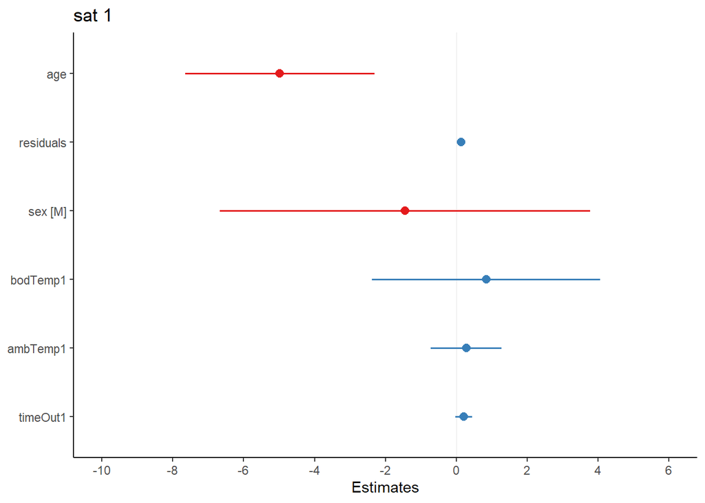

```r
plot_model(sat1.mdl)
```

### Bayesian sat 1 model with sexes combined (sex included as a random effect)

```r
stan_Sat1.mdl <- stan_glmer(sat1~age + residuals + bodTemp1 + ambTemp1 + timeOut1 + (1|family) + (1|sex),
           data = mc, algorithm = "sampling",iter = 5000,
           prior = normal(), prior_intercept = normal(),chains = 10,seed = 12345)
summary(stan_Sat1.mdl)
```

```
##
## Model Info:
##  function:     stan_glmer
##  family:       gaussian [identity]
##  formula:      sat1 ~ age + residuals + bodTemp1 + ambTemp1 + timeOut1 + (1 |
##     family) + (1 | sex)
##  algorithm:    sampling
##  sample:       25000 (posterior sample size)
##  priors:       see help('prior_summary')
##  observations: 104
##  groups:       family (62), sex (2)
##
## Estimates:
##                                         mean   sd     10%    50%    90%
## (Intercept)                             63.0   60.4  -14.3   63.2  139.8
## age                                     -3.6    1.2   -5.2   -3.6   -2.1
## residuals                                0.1    0.1    0.1    0.1    0.2
## bodTemp1                                 0.4    1.4   -1.5    0.4    2.2
## ambTemp1                                 0.5    0.5   -0.1    0.5    1.2
## timeOut1                                 0.2    0.1    0.0    0.2    0.3
## b[(Intercept) family:08_HAWA04]          4.4    7.8   -5.5    4.3   14.4
## b[(Intercept) family:09_CAFO04]         -9.5    8.0  -19.9   -9.5    0.6
## b[(Intercept) family:10_CAFO04]          0.8    7.6   -8.8    0.8   10.6
## b[(Intercept) family:19_HAWA04]          1.7    7.8   -8.2    1.8   11.6
## b[(Intercept) family:20_HAWA04]         12.7    8.1    2.3   12.6   23.1
## b[(Intercept) family:21_CAFO04]          1.2    7.7   -8.7    1.2   11.1
## b[(Intercept) family:29_LOCO04]          9.9    8.3   -0.7    9.8   20.6
## b[(Intercept) family:30_LOCO04]          7.7    8.2   -2.7    7.5   18.2
## b[(Intercept) family:31_HAWA04]         10.0    8.0   -0.2    9.9   20.2
## b[(Intercept) family:32_CAFO04]          2.5    7.9   -7.5    2.4   12.6
## b[(Intercept) family:39_FOWA04]          1.8    7.6   -8.0    1.7   11.5
## b[(Intercept) family:40_FOWA04]          1.3    7.7   -8.5    1.2   11.0
## b[(Intercept) family:41_LOCO04]         -1.4    8.0  -11.6   -1.5    8.7
## b[(Intercept) family:42_ROWA04]          2.1    6.6   -6.2    2.0   10.5
## b[(Intercept) family:43_BRBI04]         -1.6    7.7  -11.4   -1.7    8.3
## b[(Intercept) family:52_LOCO04]          4.5    8.0   -5.8    4.4   14.8
## b[(Intercept) family:53_ROWA04]        -11.3    6.6  -19.7  -11.3   -2.8
## b[(Intercept) family:54_BRBI04]         -7.0    7.9  -17.1   -6.9    3.1
## b[(Intercept) family:63_MINE04]          1.7    7.7   -8.1    1.7   11.6
## b[(Intercept) family:64_ROWA04]         -2.7    6.7  -11.2   -2.6    5.9
```

[output cut: 118 more lines]

```
## b[(Intercept) family:SEPG05]           0.0  1.0 23514
## b[(Intercept) family:STAD03]           0.0  1.0 30886
## b[(Intercept) family:STAD05]           0.0  1.0 26395
## b[(Intercept) family:SWEG03]           0.0  1.0 27420
## b[(Intercept) family:TRUP03]           0.1  1.0 12881
## b[(Intercept) family:WILG05]           0.1  1.0 12283
## b[(Intercept) sex:F]                   0.0  1.0 25532
## b[(Intercept) sex:M]                   0.0  1.0 25782
## sigma                                  0.0  1.0  6392
## Sigma[family:(Intercept),(Intercept)]  0.5  1.0  6199
## Sigma[sex:(Intercept),(Intercept)]    19.2  1.0 15394
## mean_PPD                               0.0  1.0 24971
## log-posterior                          0.2  1.0  3700
##
## For each parameter, mcse is Monte Carlo standard error, n_eff is a crude measure of effective sample size, and Rhat is the potential scale reduction factor on split chains (at convergence Rhat=1).
```

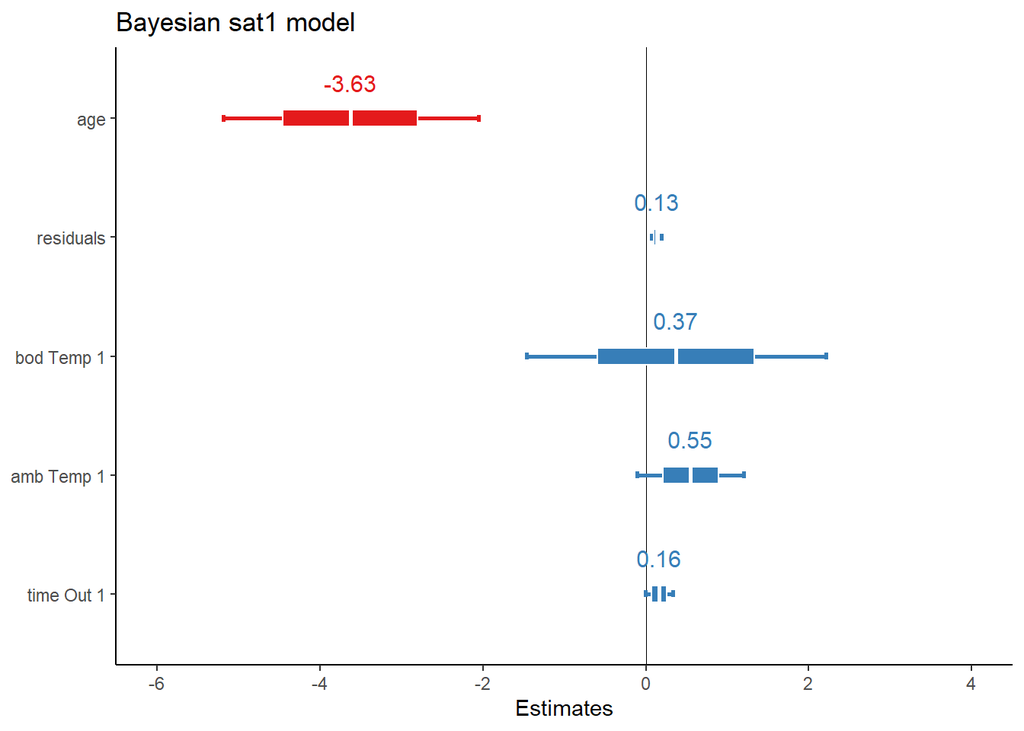

```r
plot_model(stan_Sat1.mdl,
           title = "Bayesian sat1 model",
           bpe = "median",
           vline.color = "black",
           prob.inner = .50,
           prob.outer = .80,
           show.values = TRUE,
           value.offset = .3,
           line.size = 1)
```